# Import libraries

## KNN & WNN ROC Curve

A visual representation of ROC curve for both KNN and WNN model. This indicates both models are relatively useful and good in overall performance.

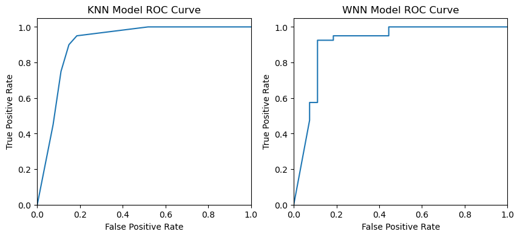

```python
fig, (knn, wnn) = plt.subplots(1, 2, figsize=(10, 4))

# KNN ROC Curve
knn.plot(knn_fpr, knn_tpr)
knn.set_xlim([0.0, 1.0])
knn.set_ylim([0.0, 1.05])
knn.set_xlabel('False Positive Rate')
knn.set_ylabel('True Positive Rate')
knn.set_title('KNN Model ROC Curve')

# WNN ROC Curve
wnn.plot(wnn_fpr, wnn_tpr)
wnn.set_xlim([0.0, 1.0])
wnn.set_ylim([0.0, 1.05])
wnn.set_xlabel('False Positive Rate')
wnn.set_ylabel('True Positive Rate')
wnn.set_title('WNN Model ROC Curve')

plt.show()
```

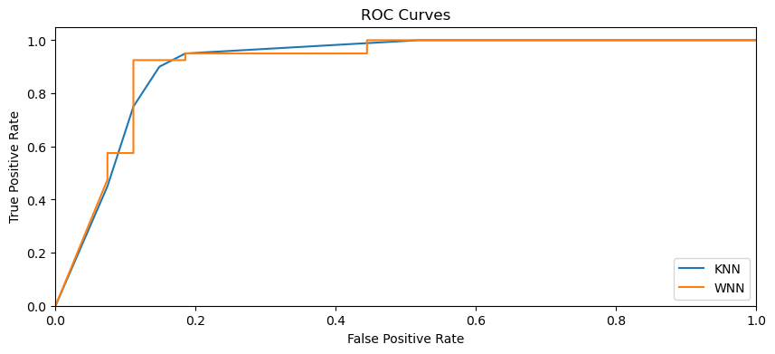

```python
fig, ax = plt.subplots(figsize=(10, 4))

# KNN ROC Curve
ax.plot(knn_fpr, knn_tpr, label='KNN')
ax.set_xlim([0.0, 1.0])
ax.set_ylim([0.0, 1.05])

# WNN ROC Curve
ax.plot(wnn_fpr, wnn_tpr, label='WNN')
ax.set_xlabel('False Positive Rate')
ax.set_ylabel('True Positive Rate')
ax.set_title('ROC Curves')
ax.legend()

plt.show()
```

# Simulate Part

Two function are created both Normalizing function and simulating function.

The purpose of normalizaing function is to normalize simulate dataframe in to common range then relate back to the KNN and WNN model for futhur calculation.

The simulating function is to approximate a patient's health state after 20 years based on its current status without any treatment in placed.

```python
# Normalize Function
# This function use raw data to normalize simulate data
def normalize_function(s_data,r_data):
    normalized_s_data = s_data.apply(lambda x: (x - r_data[x.name].min()) / (r_data[x.name].max() - r_data[x.name].min()))
    return normalized_s_data
```

```python
# Create a functions that can simulate the feachers change in the further 20 years.
def feature_simulater(s_data):
    simulated_data = s_data.copy()
    simulated_data.loc[0, 'age'] = simulated_data.loc[0, 'age'] + 1 # age
    if simulated_data.loc[0, 'cp'] >= 0.1:
        simulated_data.loc[0, 'cp'] = simulated_data.loc[0, 'cp'] - random.choice([0, 0.1, 0.2]) # Chest Pain type chest pain type
    simulated_data.loc[0, 'trtbps'] = simulated_data.loc[0, 'trtbps'] + 2 # resting blood pressure
    simulated_data.loc[0, 'chol'] = simulated_data.loc[0, 'chol'] + 3 # cholestoral in mg/dl fetched via BMI sensor
    simulated_data.loc[0, 'fbs'] = simulated_data.loc[0, 'fbs'] + random.choice([0, 0.1]) # fasting blood sugar
    simulated_data.loc[0, 'thalachh'] = simulated_data.loc[0, 'thalachh'] - 1 # maximum heart rate achieved
    if simulated_data.loc[0, 'exng'] < 1:
        simulated_data.loc[0, 'exng'] = simulated_data.loc[0, 'exng'] + random.choice([0, 0.05]) # exercise induced angina
    return simulated_data
```

```python
## Create simulate dataframe
simulate_data={
    'age': [42],
    'sex': [1],
    'cp': [1],
    'trtbps': [92],
    'chol': [194],
    'fbs': [0],
    'restecg': [1],
    'thalachh': [192],
    'exng': [1],
    'oldpeak': [0.8],
    'slp': [2],
    'caa': [0],
    'thall': [2]
}
simulate_data = pd.DataFrame(simulate_data)
```

## KNN Simulate

```python
i = 0
while i<=20:
    if i == 0:
        X_test=normalize_function(simulate_data,df_raw)
        y_pred = knn_classifier.predict(X_test)
        if(y_pred == 0.):
            print("There's a small chance you'll have a heart attack now.")
        else:
            print("There's a high chance you'll have a heart attack now.")
            break
    elif i == 20:
        print("And, you also have a small chance of having a heart attack in the further 20 years.")
    else:
        simulate_data = feature_simulater(simulate_data)
        X_test=normalize_function(simulate_data,df_raw)
        y_pred = knn_classifier.predict(X_test)
        if(y_pred == 1.):
            print("But you might have a heart attack after " + str(i) + " years.")
            break
    i+=1
```

```
There's a small chance you'll have a heart attack now.
But you might have a heart attack after 4 years.
```